# Projet Clustering et réduction de dimensions (Ensai, 3A)

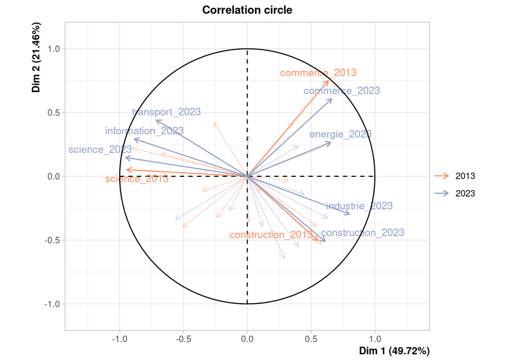

```r
plot(res.MFAprop_horsMayotte, choix = "var", axes = c(1, 2),
     habillage = "group",
     palette = brewer.pal(3, "Set2"),
     repel = TRUE,
     cex = 0.9,
     select = "contrib 10")
```

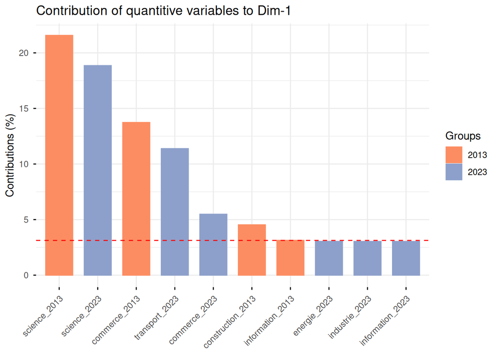

```r
fviz_contrib(res.MFAprop_horsMayotte, choice = "quanti.var", axes = 1, top = 10,
             palette = brewer.pal(3, "Set2")[2:3])
```

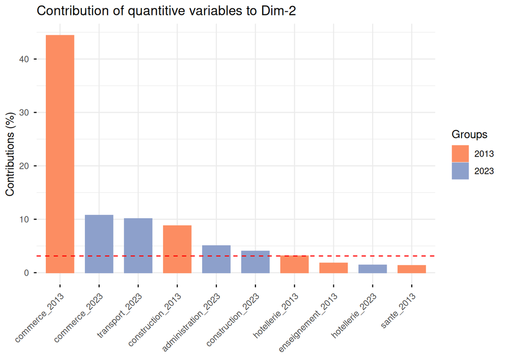

```r
fviz_contrib(res.MFAprop_horsMayotte, choice = "quanti.var", axes = 2, top = 10,
             palette = brewer.pal(3, "Set2")[2:3])
```

Les principaux commentaires écrits précédemment restent valables. Le retrait de Mayotte de la construction des axes a toutefois rendu très importante la part du secteur du commerce, plus spécifiquement celle de 2013.

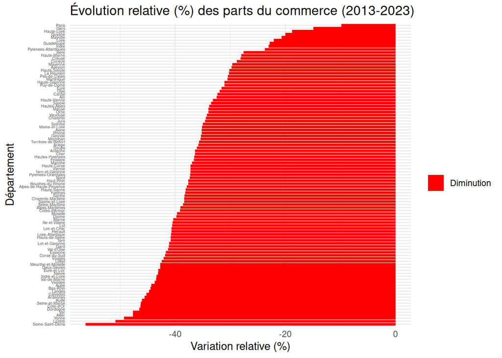

```r
bdd_prop_evolution_commerce <- bdd_prop %>%
  mutate(
    variation_relative = (commerce_2023 - commerce_2013) / commerce_2013 * 100
  ) %>%
  arrange(desc(variation_relative))

ggplot(bdd_prop_evolution_commerce, aes(x = reorder(departement, variation_relative),
                                   y = variation_relative, fill = variation_relative > 0)) +
  geom_bar(stat = "identity") +
  coord_flip() +
  labs(title = "Évolution relative (%) des parts du commerce (2013-2023)",
       x = "Département",
       y = "Variation relative (%)",
       fill = "") +
  scale_fill_manual(values = c("red", "green"), labels = c("Diminution", "Augmentation")) +
  theme_minimal() +
  theme(axis.text.y = element_text(size = 4))
```

```r
bdd_prop_evolution_commerce %>%
  dplyr::select(departement, commerce_2013, commerce_2023) %>%
  arrange(desc(commerce_2013))
```

| departement | commerce_2013 | commerce_2023 |
| --- | --- | --- |
| Mayotte | 58.333333 | 46.284830 |
| Ardennes | 35.080058 | 19.103314 |
| Yonne | 32.909931 | 16.689420 |
| Territoire de Belfort | 32.100396 | 20.647773 |
| Doubs | 30.742540 | 19.658647 |
| Allier | 30.221424 | 15.809098 |
| Deux-Sevres | 30.167921 | 17.289221 |
| Haute-Saone | 30.147698 | 18.660287 |
| Loiret | 29.865576 | 17.192501 |
| Aube | 29.824561 | 16.591618 |

[output cut: 91 more lines]

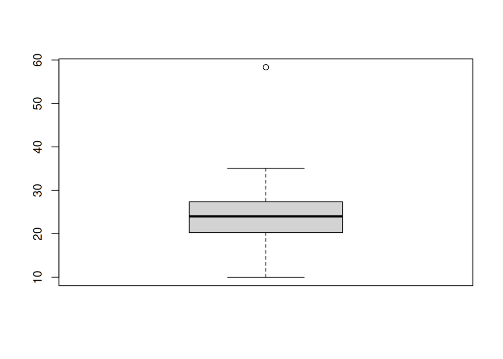

```r
boxplot(bdd_prop_evolution_commerce$commerce_2013)
```

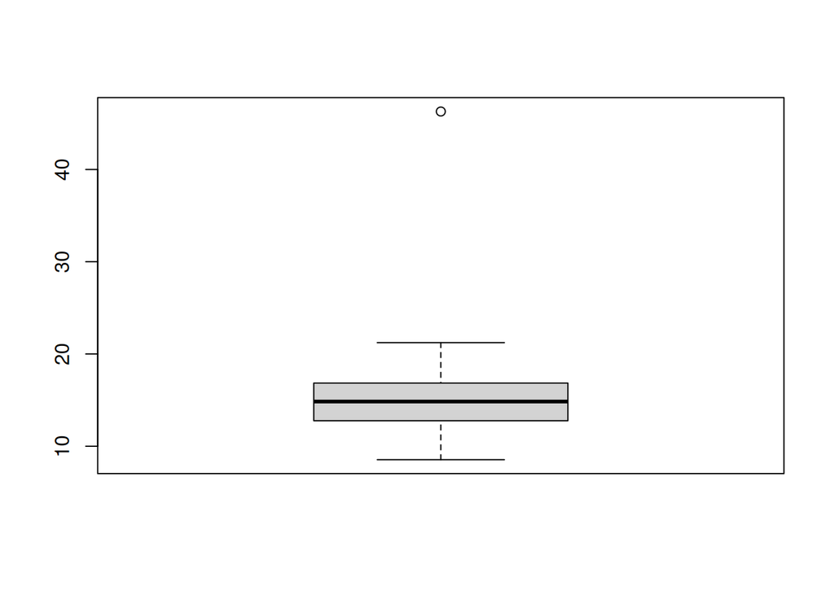

```r
boxplot(bdd_prop_evolution_commerce$commerce_2023)
```

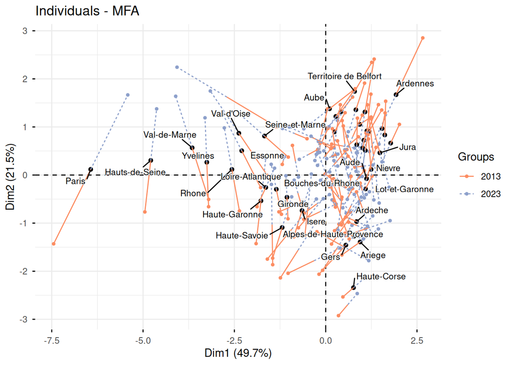

```r
fviz_mfa_ind(res.MFAprop_horsMayotte, partial = "all", invisible = "ind.sup",
             repel = TRUE, labelsize = 3,
             select.ind = list(
               cos2 = 0.7,
               name = as.data.frame(res.MFAprop_horsMayotte$ind$coord) %>%
                                 # filter(Dim.1 > 0.5 | Dim.1 < -0.5 |
                                 #          Dim.2 > 0.5 | Dim.2 < -0.5) %>%
                                 rownames()),
             geom = "point",
             palette = brewer.pal(3, "Set2")[2:3]) +
  geom_text_repel(aes(label = name), size = 3,
                  box.padding = 0.5,
                  bg.color = "white",
                  bg.r = 0.1)
```

En enlevant Mayotte, l’AFM devient nettement plus lisible et plus représentative des autres départements.

# Question 3 : classification des départements

## Nuage des individus moyens

```r
c.MFA <- HCPC(res.MFAprop_horsMayotte, nb.clust=-1, graph = FALSE)
```

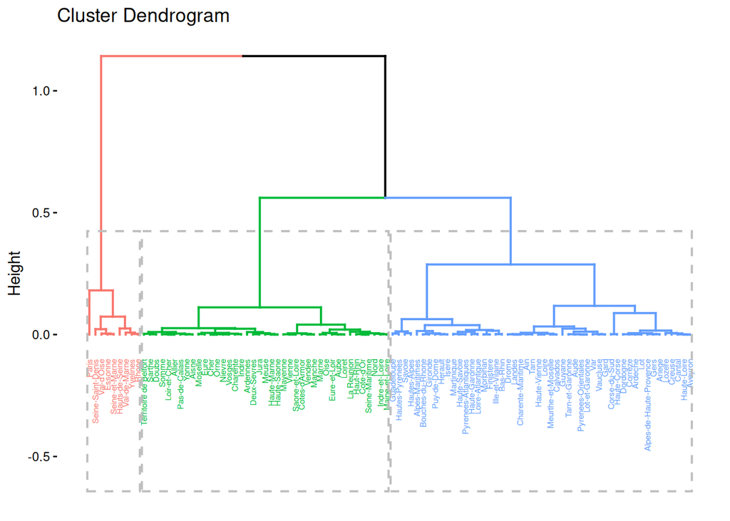

```r
fviz_dend(c.MFA, k = 5, show_labels = TRUE, rect = TRUE, cex = 0.4)
```

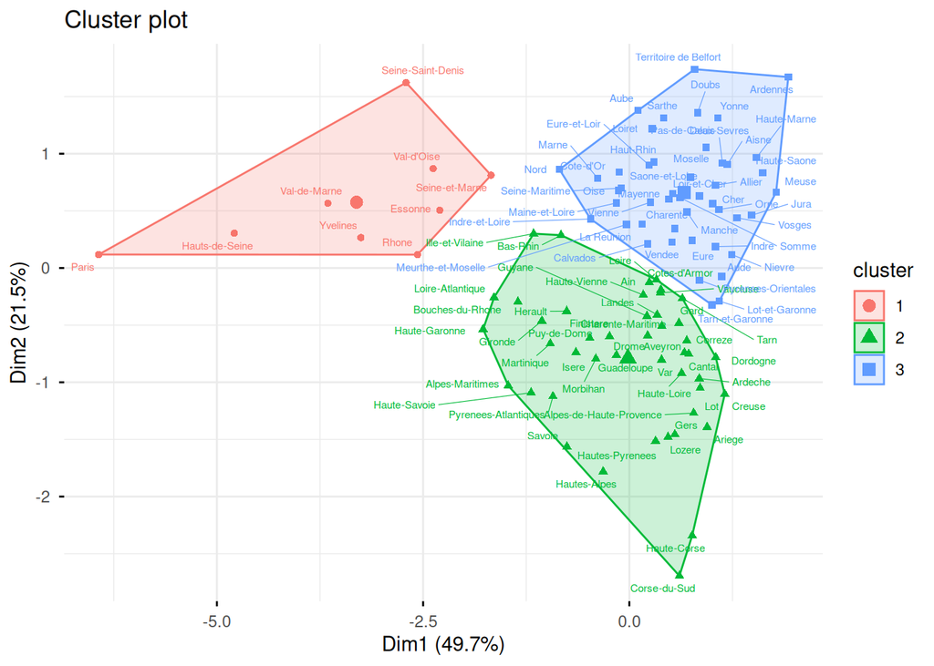

```r
fviz_cluster(c.MFA, ggtheme = theme_minimal(), repel = TRUE, labelsize = 6)
```

```r
c.MFA$data.clust %>%
  tbl_summary(by = clust)
```

| **Characteristic** | **1** N = 9<sup>1</sup> | **2** N = 45<sup>1</sup> | **3** N = 46<sup>1</sup> |
| --- | --- | --- | --- |
| industrie_2013 | 3.13 (2.93, 3.51) | 5.14 (4.54, 6.15) | 4.77 (4.33, 5.33) |
| energie_2013 | 0.04 (0.01, 0.06) | 0.49 (0.24, 1.05) | 0.49 (0.24, 0.98) |
| environnement_2013 | 0.17 (0.15, 0.29) | 0.27 (0.15, 0.36) | 0.48 (0.33, 0.66) |
| construction_2013 | 10.99 (9.82, 11.86) | 15.42 (12.99, 16.87) | 12.96 (12.02, 14.89) |
| commerce_2013 | 18.6 (17.3, 21.3) | 20.3 (19.0, 22.5) | 27.5 (25.7, 29.2) |
| transport_2013 | 4.00 (3.25, 6.36) | 0.84 (0.70, 1.06) | 0.77 (0.61, 0.96) |
| hotellerie_2013 | 1.70 (1.47, 1.93) | 4.67 (3.75, 6.58) | 3.93 (3.30, 4.78) |
| information_2013 | 7.07 (6.22, 8.58) | 3.03 (2.58, 3.91) | 3.25 (2.61, 3.43) |
| finance_2013 | 1.06 (0.89, 1.18) | 0.65 (0.55, 0.80) | 0.77 (0.64, 0.93) |
| immobilier_2013 | 1.20 (1.07, 1.65) | 1.89 (1.28, 2.46) | 1.71 (1.46, 2.12) |
| science_2013 | 17.60 (14.25, 19.89) | 10.10 (8.98, 12.10) | 9.70 (8.14, 10.70) |
| administration_2013 | 6.47 (6.31, 6.82) | 5.77 (4.99, 6.69) | 5.23 (4.71, 5.80) |
| enseignement_2013 | 6.31 (6.26, 6.94) | 5.55 (4.81, 6.59) | 4.47 (3.86, 5.18) |
| sante_2013 | 7.08 (6.52, 7.44) | 10.06 (9.02, 10.72) | 8.88 (7.60, 9.40) |
| culture_2013 | 5.47 (5.18, 6.07) | 5.07 (4.62, 5.87) | 4.89 (4.31, 5.32) |
| services_2013 | 6.19 (5.26, 7.09) | 8.49 (7.46, 9.04) | 9.30 (8.74, 9.95) |
| industrie_2023 | 2.13 (1.80, 2.80) | 5.58 (4.82, 7.37) | 5.85 (5.50, 6.44) |
| energie_2023 | 0.78 (0.47, 0.97) | 2.89 (1.53, 4.20) | 4.78 (3.36, 6.09) |
| environnement_2023 | 0.11 (0.09, 0.13) | 0.18 (0.13, 0.23) | 0.25 (0.15, 0.34) |
| construction_2023 | 4.84 (4.23, 5.92) | 8.77 (7.50, 9.40) | 7.71 (6.62, 8.81) |
| commerce_2023 | 10.86 (10.00, 12.08) | 13.33 (12.22, 14.46) | 16.80 (15.81, 18.10) |
| transport_2023 | 14.8 (13.8, 17.1) | 5.2 (3.7, 6.8) | 6.1 (4.9, 7.7) |
| hotellerie_2023 | 2.00 (1.95, 2.04) | 3.55 (2.62, 4.48) | 2.83 (2.20, 3.21) |
| information_2023 | 8.39 (8.01, 9.58) | 4.56 (3.87, 5.55) | 4.74 (4.06, 5.33) |
| finance_2023 | 0.54 (0.47, 0.56) | 0.50 (0.41, 0.62) | 0.60 (0.49, 0.69) |
| immobilier_2023 | 1.98 (1.64, 2.14) | 2.75 (2.59, 3.29) | 2.85 (2.59, 3.24) |
| science_2023 | 20.19 (18.33, 22.20) | 11.86 (10.75, 13.96) | 11.52 (10.44, 13.01) |
| administration_2023 | 9.14 (8.30, 9.34) | 11.23 (9.78, 12.05) | 9.69 (9.09, 10.28) |
| enseignement_2023 | 6.61 (5.75, 6.91) | 5.54 (5.00, 6.44) | 4.56 (4.30, 5.07) |
| sante_2023 | 4.51 (4.37, 4.63) | 6.79 (6.10, 7.41) | 5.70 (5.10, 6.56) |
| culture_2023 | 3.72 (3.30, 4.34) | 4.42 (4.04, 4.81) | 4.11 (3.61, 4.66) |
| services_2023 | 7.56 (6.65, 8.15) | 10.96 (10.22, 11.57) | 10.41 (9.94, 11.16) |

<sup>1</sup> Median (Q1, Q3)

Les trois clusters (nombre choisi automatiquement avec un algorithme répliquant le critère du coude) obtenus par CAH semblent très distincts. Le premier (rouge) correspond globalement à la région parisienne, spécialisée plutôt dans des secteurs innovants comme les technologies de l’information et de la communication ou les activités scientifiques. Le second cluster (vert) semble constitué des départements de l’Ouest et du Sud-Est de la France : Loire Atlantique, Dordogne, Finistère, Alpes-Maritimes, Savoie, Corse… Ces départements seraient davantage caractérisés par une production primaire, en 2013 et/ou en 2023. Le troisième cluster (bleu) semble s’apparenter au Nord et au centre de la France, avec le Pas-de-Calais, les Vosges ou encore le Jura. Il s’agirait de départements spécialisés plutôt dans des activités commerciales.

## Nuage des individus 2013

```r
c.MFA2013 <- HCPC(as.data.frame(
  res.MFAprop_horsMayotte$ind$coord.partiel[
    grep("2013$", rownames(res.MFAprop_horsMayotte$ind$coord.partiel)), ]),
  nb.clust=-1, graph = FALSE)
```

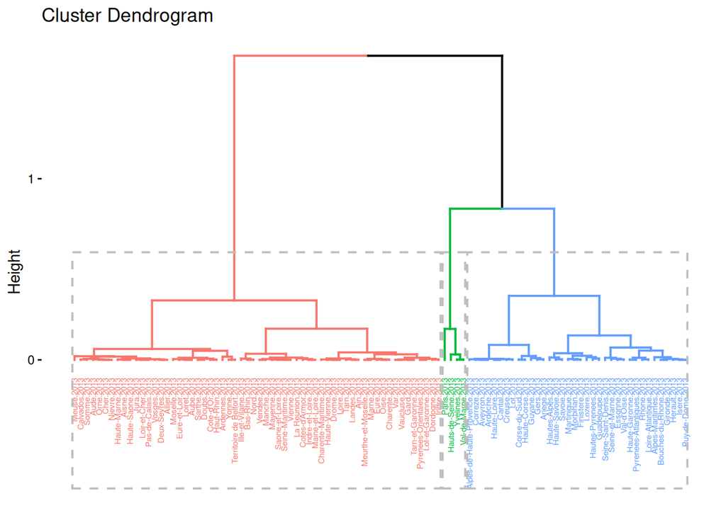

```r
fviz_dend(c.MFA2013, k = 5, show_labels = TRUE, rect = TRUE, cex = 0.4)
```

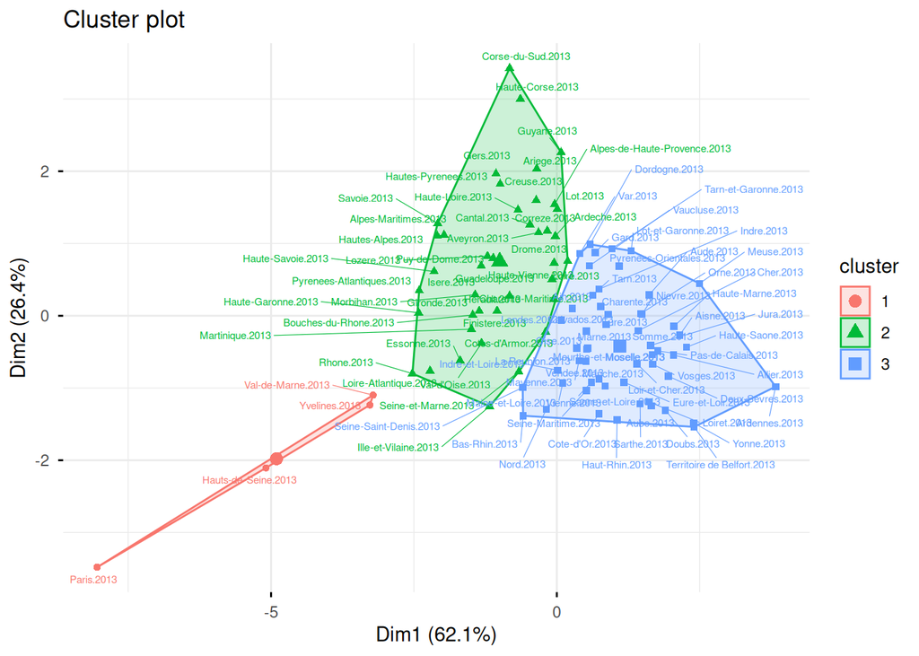

```r
fviz_cluster(c.MFA2013, ggtheme = theme_minimal(), repel = TRUE, labelsize = 6)
```

Ce graphique doit être mis en relation avec la représentation des composantes de 2013 dans le cercle des corrélations précédent. Le premier cluster, représentant la région parisienne, est très hétérogène en 2013, contrairement aux autres clusters.

## Nuage des individus 2023

```r
c.MFA2023 <- HCPC(as.data.frame(
  res.MFAprop_horsMayotte$ind$coord.partiel[
    grep("2023$", rownames(res.MFAprop_horsMayotte$ind$coord.partiel)), ]),
  nb.clust=-1, graph = FALSE)
```

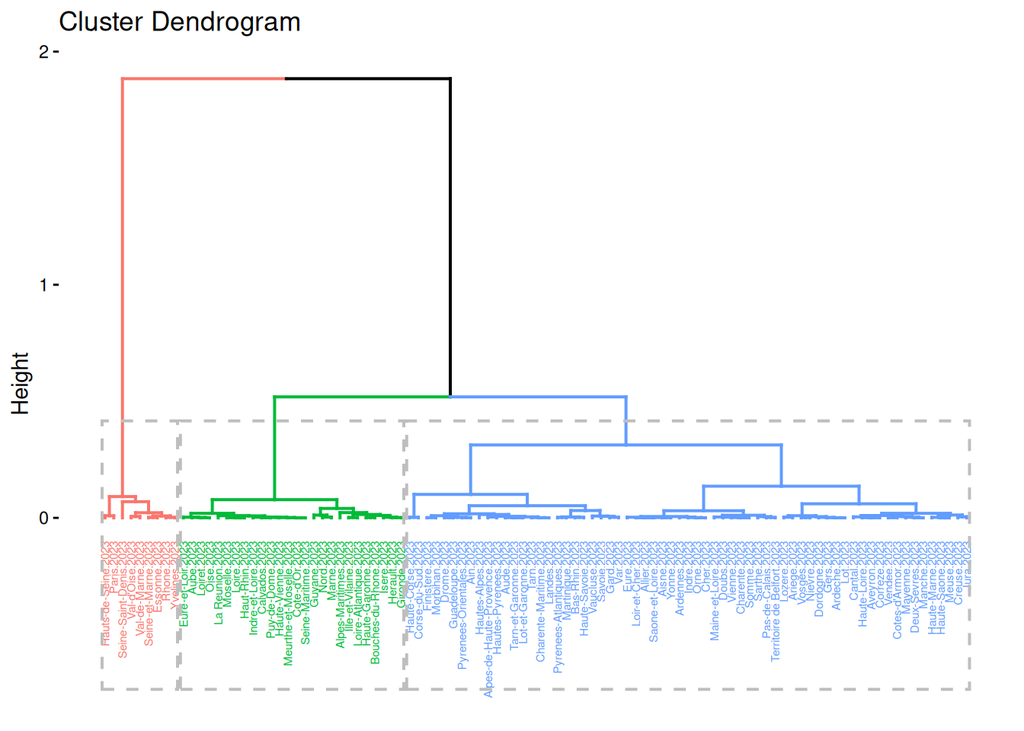

```r
fviz_dend(c.MFA2023, k = 5, show_labels = TRUE, rect = TRUE, cex = 0.4)
```

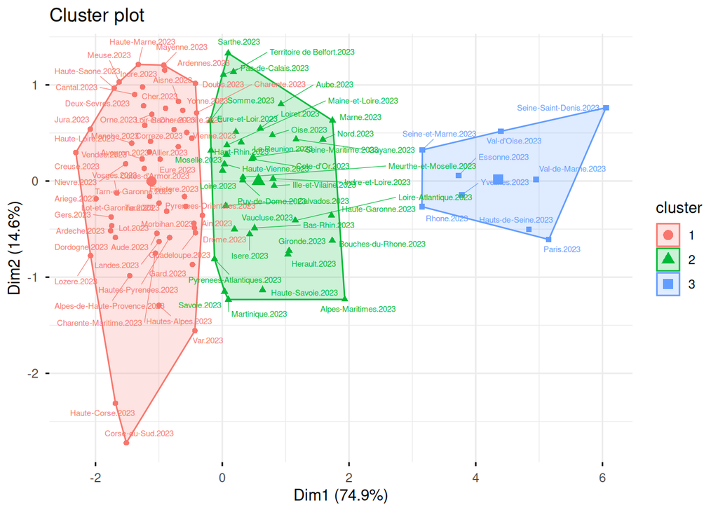

```r
fviz_cluster(c.MFA2023, ggtheme = theme_minimal(), repel = TRUE, labelsize = 6)
```

On peut voir que l’inertie expliquée sur l’axe 1 est particulièrement importante et que les clusters sont distincts. Cela peut signifier qu’il est plus simple de distinguer les départements en 2023 qu’en 2013, et que les spécialisations sont donc plus marquées.

# Question 4 : classification des variables

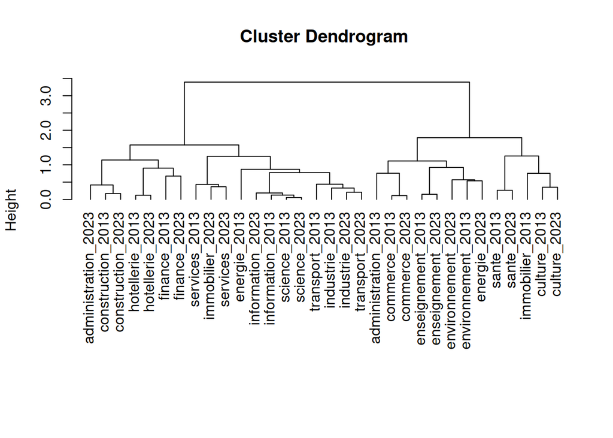

```r
# 1. Classification hiérarchique des variables
res_clust <- hclustvar(
  X.quanti = bdd_prop_mfa
)

# 2. Dendrogramme
plot(res_clust)
```

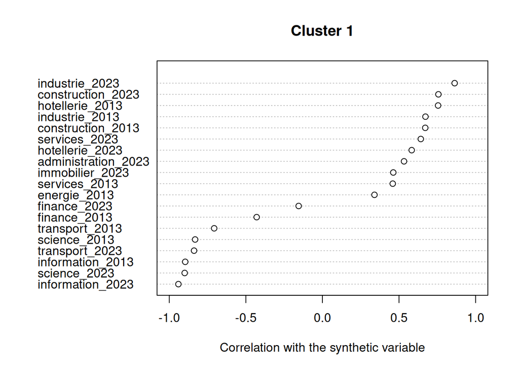

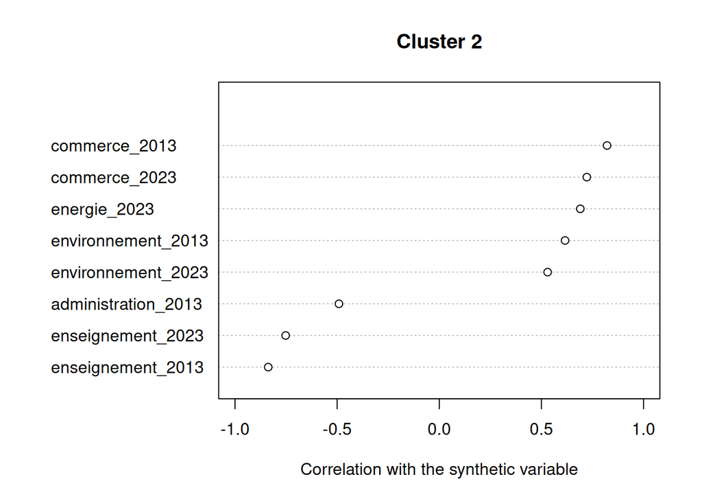

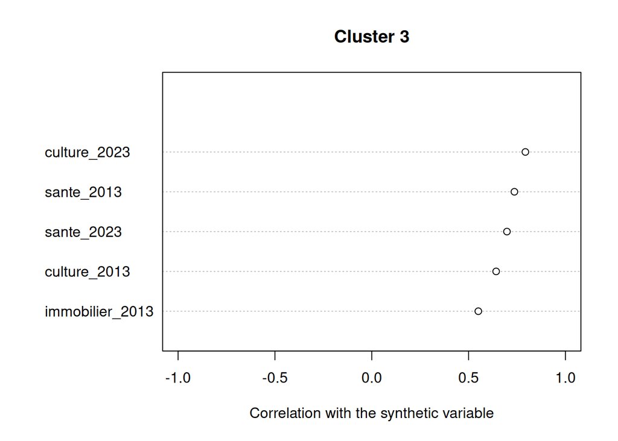

```
## $coord.quanti
## $coord.quanti$Cluster1
##                          dim 1
## information_2023    -0.9404891
## science_2023        -0.8994445
## information_2013    -0.8958889
## transport_2023      -0.8383388
## science_2013        -0.8312848
## transport_2013      -0.7068960
## finance_2013        -0.4295202
## finance_2023        -0.1552894
## energie_2013         0.3396089
## services_2013        0.4590220
## immobilier_2023      0.4625086
## administration_2023  0.5325639
## hotellerie_2023      0.5827125
## services_2023        0.6421236
## construction_2013    0.6713019
## industrie_2013       0.6725930
## hotellerie_2013      0.7550782
## construction_2023    0.7571719
## industrie_2023       0.8631338
##
## $coord.quanti$Cluster2
##                          dim 1
## enseignement_2013   -0.8373203
## enseignement_2023   -0.7520697
## administration_2013 -0.4911363
## environnement_2023   0.5304365
## environnement_2013   0.6158020
## energie_2023         0.6904619
## commerce_2023        0.7223688
## commerce_2013        0.8213342
##
## $coord.quanti$Cluster3
##                     dim 1
## immobilier_2013 0.5502148
## culture_2013    0.6422154
## sante_2023      0.6980624
## sante_2013      0.7365200
## culture_2023    0.7932034
##
##
## $coord.levels
## $coord.levels$Cluster1
## [1] "No categorical variables in this cluster"
##
## $coord.levels$Cluster2
## [1] "No categorical variables in this cluster"
##
## $coord.levels$Cluster3
## [1] "No categorical variables in this cluster"
```

```r
# 3. Choix du nombre de classes
part <- cutreevar(res_clust, k = 3)

plot(part)
```

```r
# # Variables par classe
# part$var
#
# # Gain de cohésion
# part$sim
```

Difficultés à classer les variables, on retrouve pas les mêmes groupes que précédemment.

# Synthèse de nos résultats

Nous étudiants ici les créations d’entreprise à l’échelle des départements français et entre 2013 et 2023.

Deux méthodes sont possibles : - analyser le nombre brut d’entreprises créées par secteur et par département, - étudier l’importance relative des secteurs d’activité parmi l’ensemble des créations d’entreprise de chaque département.

Cette dernière méthode permet une meilleure comparaison des dynamiques de production entre départements. En effet, lorsqu’on compare uniquement le nombre d’entreprises créées d’un département à l’autre et d’un secteur à un autre, on se heurte à un effet taille : les départements les plus productifs le sont, généralement, pour la majorité des secteurs d’activité. Parmi les départements concernés se trouvent ceux les plus peuplés : ceux de la région Île-de-France. Les productions dans l’ensemble des secteurs sont alors corrélées, ce qui invisibilise des relations entre des secteurs pour lesquels la production est plus faible.

A l’inverse, lorsqu’on étudie l’ensemble des secteurs simultanément relativement aux créations d’entreprises de chaque département, on constate des relations fortes :

- Tout d’abord, l’industrie et la construction sont deux secteurs liés, c’est-à-dire qu’on département qui connaît beaucoup de créations d’entreprises en construction va également connaître de nombreuses créations d’entreprises industrielles.
- De même, des secteurs très innovants comme la science et l’information sont regroupés, et semblent s’opposer aux deux secteurs précédents. Cela indique que les départements pour lesquels il y a de nombreuses créations d’entreprises en science ou en information sont des départements où la production industrielle sera relativement moins présente. Cependant, cela ne veut pas dire qu’il y a peu d’entreprises créées pour l’industrie ou la construction dans ces départements ; il y en a juste nettement moins en comparaison aux secteurs de l’information et de la science. A l’inverse, certains départements moins productifs peuvent être considérés comme industriels alors même qu’ils connaissent moins de créations d’entreprises en industrie que d’autres départements. C’est le cas si les entreprises qui y sont créées, relativement peu nombreuses, sont avant tout industrielles.
- Enfin, le commerce semble être indépendant des autres secteurs. Autrement dit, certains départements sont concernés par des créations d’entreprises commerciales ou industrielles, d’autres par des entreprises commerciales ou scientifique, et d’autres principalement commerciales.

Notons que la différence entre les deux périodes est peu visible : les secteurs sont généralement liés deux-à-deux d’une période à l’autre, soulevant un référentiel commun : qu’importe les variations, les hiéérarchies entre les secteurs semblent préserver sur dix ans.

Il est finalement possible de classer les secteurs en catégories.